# Profiling code

Di Cook, Heike Hofmann  
3/3/2014

### Signs of the inexperienced programmer

- *Vodoo Code* - code that you don’t quite understand, but that ‘has to be there’ so that everything works.
- *Yo-Yo Code* - multiple conversions between different representations (e.g. numeric <-> character) for simple operations.
- *Bulldozers* - code that may looks nicely structured (and general), but only works in one specific application.

### Check functions

What does this code do? How does it work?

```
stopifnot <- function (...)
{
    k <- length(ll <- list(...))
    if (k == 0L)
        return(invisible())
    mc <- match.call()
    for (i in 1L:k) if (!(is.logical(r <- ll[[i]]) && !any(is.na(r)) &&
        all(r))) {
        ch <- deparse(mc[[i + 1]], width.cutoff = 60L)
        if (length(ch) > 1L)
            ch <- paste(ch[1L], "....")
        stop(paste(ch, " is not ", if (length(r) > 1L)
            "all ", "TRUE", sep = ""), call. = FALSE)
    }
    invisible()
}
```

### Step-by-step code checking

The `browser()` function allows stepping through your code.

```r
help(browser)
```

- `n`= executes the next line of code
- `c`= continue execution until the end of the function, and exit
- `where` gives you the stack information, the trace of the active function calls
- `Q` exits browser()

### Simple alternatives

Putting in

- `cat()`
- `str()`
- `head()`
- `summary()`
- `print()`

are simple ways to build code up step-wise ensuring that each piece works

### What is this?

`0L`, `1L`

```r
cat(0L)
```

```
0
```

```r
cat(1L)
```

```
1
```

### Let's try browser()

`stopifnot2()` function has `browser()` in first line of function

```
x <- 1
stopifnot2(x==x, 1+1==2, c(7+5==11.99999, 1+1==2))
```

Browser enables:

- printing of result of each line
- checking changes to values
- make sure that it results in what is expected

### debug()

`debug()` automatically places a `browser()` in the first line of function

`undebug()` removes it.

### Setting error handling

- `options(error=recover)` will drop user into `browser()` upon an error
- `options(error=NULL)` default, do nothing
- `options(warn=2)` sets maximum number of warnings to be 2
- `options(warn=0)` warnings are stored until top level function finishes
- `options(warn=-1)` ignore all warnings

### Traceback

`traceback()` shows which function it failed in

```r
f <- function(x) {
  w(x)
    g(h(x))
    w(x)
}
g <- function(x) {
    a <- 10
    x
}

h <- function(x) {
    w(x)
    w(x)
}

w <- function(x) {
    if (sample(10, 1) == 1) stop("This is an error!")
}

f()
traceback()
```

```
No traceback available
```

### Traceback

```
> f()
Error in w(x) : This is an error!
> traceback()
5: stop("This is an error!") at #2
4: w(x) at #2
3: h(x) at #3
2: g(h(x)) at #3
1: f()
```

### Fix this

`larger(x,y)` is supposed to return the larger of the two vectors element-by-element

```r
larger <- function(x, y) {
  y.is.bigger <- y > x
    x[y.is.bigger] <- y[y.is.bigger]
    x
}
larger(c(1, 5, 10), c(2, 4, 11))
```

```
[1]  2  5 11
```

```r
larger(c(1, 5, 10), 6)
```

```
[1]  6 NA 10
```

### More signs of inexperienced programmers

- Violation of the language model
- e.g. R is vector oriented language - for loops should be used sparingly,
- e.g. use of rbind
- Insufficient knowledge of the language. We’re all guilty of that at different levels
- Reading other people’s code helps improve our language knowledge!

### Removing for loops

```r
x <- floor(runif(100)*4)
y <- vector("character", length=length(x))
for (i in 1:length(x)) {
   y[i] <- switch (x[i]+1, "Sun", "Rain", "Snow", "Hail", default=NA)
}

table(y)
```

```
y
Hail Rain Snow  Sun
  32   23   22   23
```

### Removing for loops

```r
# the switch statement on the previous slide is equivalent to the following lines:
for (i in 1:length(x)) {
  if (x[i] == 0) y[i] <- "Sun"
  if (x[i] == 1) y[i] <- "Rain"
  if (x[i] == 2) y[i] <- "Snow"
  if (x[i] == 3) y[i] <- "Hail"
}

# using R's vectors we can reduce this to a single line:
y <- c("Sun", "Rain", "Snow", "Hail")[x+1]
```

### Getting better

- Read good code, try to emulate
- READ code
- spot GOOD code - how?
- Re-read your own (old) code CRITICALLY.
- Possible questions: how can I break the code? how can I write this shorter? how can I make this more general?
- Foremost: PRACTICE!

### Spotting bad code

- Ken Thompson: keep the number of indentations down, high number of local variables is suspicious
- Hadley Wickham: functions with more than ten lines are suspicious, highly repetitive code
- Generally Good Practices: indentation and spacing, comments, clear naming convention

### Profiling

- `system.time()` and `proc.time()`
- profr
- optimization example

### What is profiling

- Collect information on code performance:
- memory usage
- frequency and duration of function calls
- Goal: optimization of code

### system.time()

- Probably simplest of all measures
- Evaluates the time spent in the whole expression
- doesn’t give any clues about what is done at a lower level
- Alternative: `proc.time()`

### A previous example

Temperature trends in NASA data

```r
nasa <- readRDS(file="../data/nasadata.rds")
library(ggplot2)
```

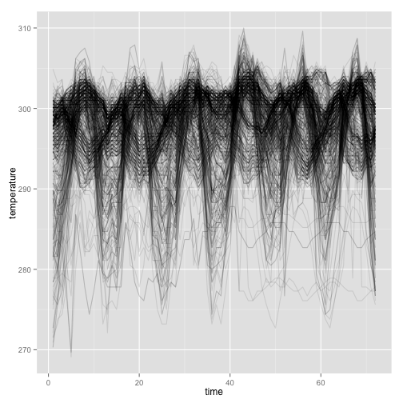

```r
qplot(time, temperature, group=interaction(x,y),
      geom="line", data=nasa, alpha=I(0.1))
```

### Compute temperature trends

```r
library(MASS)
# Block #1
ptm <- proc.time()
nasa.trend<-unique(nasa[,c("x","y")])
nasa.trend$temperature <- 0
ny<-length(unique(nasa$y))
for (i in unique(nasa$x)) {
  for (j in unique(nasa$y)) {
    x <- subset(nasa, x==i&y==j)
    nasa.trend$temperature[(i-1)*ny+j] <- coefficients(rlm(temperature~year+month, data=x))[2]
  }
}
proc.time() - ptm
```

```
   user  system elapsed
 12.986   1.125  14.118
```

```r
#   user  system elapsed
#  7.234   1.287   8.507
```

### Computer temperature trends, second method

```r
# Block #2
library(plyr)
model.fn<-function(x) {
  return(coefficients(rlm(temperature~year+month, data=x))[2])
}

# block 2
ptm <- proc.time()
nasa.trend.plyr<-ddply(nasa, c("x", "y"), model.fn)
proc.time() - ptm
```

```
   user  system elapsed
  2.242   0.054   2.300
```

```r
#   user  system elapsed
#  2.801   0.226   3.016
```

### Computer temperature trends, third method

```r
library(dplyr)
model.fn2<-function(temperature, year, month) {
  return(coefficients(rlm(temperature~year+month))[2])
}

# block 3
ptm <- proc.time()
nasa.trend.dplyr <- group_by(nasa, x,y) %.%
  summarise(mfn = model.fn2(temperature, year, month))
proc.time() - ptm
```

```
   user  system elapsed
  0.705   0.037   0.744
```

```r
#   user  system elapsed
#  1.953   0.040   2.187
# relatively small speed-up
```

### Profiling Code

Second method is much faster than the first. Why?

profr package:

- wrapper around function `Rprof`
- call stack is written every 0.02 seconds (interval) into a temporary file
- output file is processed to produce a summary of the usage
- time measurements varies by platform: on Unix-alike time is CPU time of the R process (excludes time waiting for input)
- Note: profiling takes time, too; once the timer goes off, the information is not recorded until the next timing click (probably in the range 1–10 msecs). Can’t go below that.

### Profiling each of the blocks

```r
library(profr)
block2 <- profr(
   nasa.trend.plyr<-ddply(nasa, c("x", "y"), model.fn)
)
head(block2, 10)
```

```
                     f level time start  end  leaf source
8               in_dir     1 2.12     0 2.12 FALSE   <NA>
9             evaluate     2 2.12     0 2.12 FALSE   <NA>
10       evaluate_call     3 2.12     0 2.12 FALSE   <NA>
11              handle     4 2.12     0 2.12 FALSE   <NA>
12 withCallingHandlers     5 2.12     0 2.12 FALSE   base
13         withVisible     6 2.12     0 2.12 FALSE   base
14                eval     7 2.12     0 2.12 FALSE   base
15                eval     8 2.12     0 2.12 FALSE   base
16               profr     9 2.12     0 2.12 FALSE  profr
17                 try    10 2.12     0 2.12 FALSE   base
```

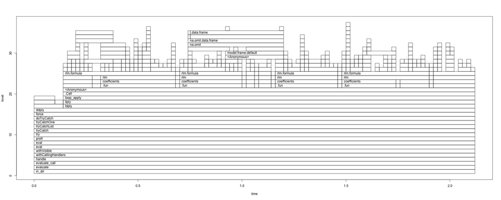

```r
plot(block2)
```

How do these ‘bridges’ occur when plotting the output?